# My visual data story

## About this data

This dataset is taken from my observation during my workouts from March to May. Each observation logs a workout day, a workout phase, the muscle group being trained, and total reps to see if there could be any interesting trend or pattern in my personal workout plan. Each person will have their own workout goals and plans so I think that there is a lot of potential for this kind of observational data to be interesting and unique for each individual. My main focus on this data is to derive summary statistics from this data. Since we are working multiple different muscles, aggregation based on the group of muscles is very easy, allowing us to observe any pattern over the data collection period. Ultimately this will help me understand my current progress and help me with any changes that I might make to my workout plan later on.

## Which muscles got the most work?

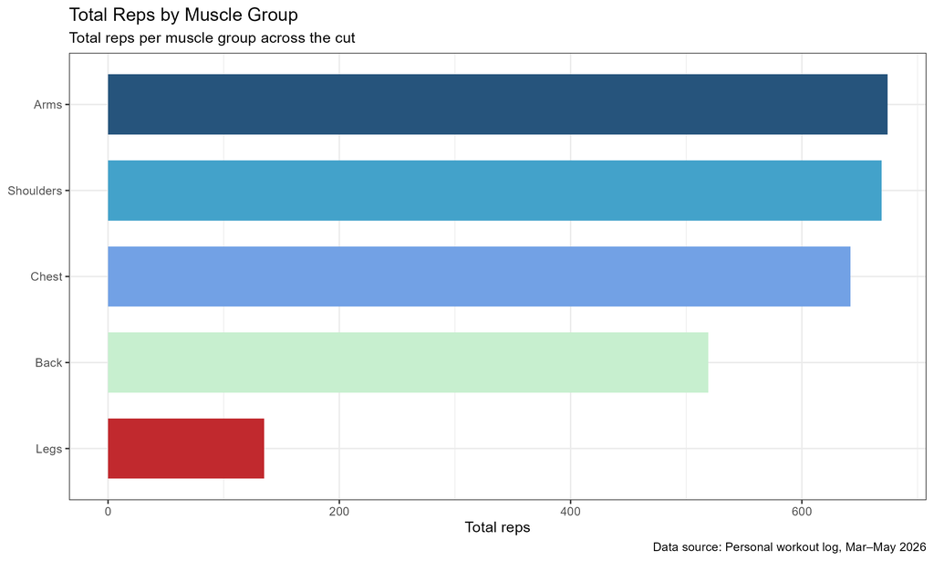

This is straightforward and demonstrate the suitability of this dataset in terms of computing summary statistics. From the graph, it seems that arms and shoulders are my two most worked muscle group, followed by chest, with the least being legs (surprising). I think that the huge amount of reps for arms could be explained because I count each arm as contributing to a set so realistically the total amount of reps for arms could be cut in half. The same can also be said for shoulders because some excersise work each shoulder individually but not every excersise in a workout day does.

## Did volume stay consistent over the week?

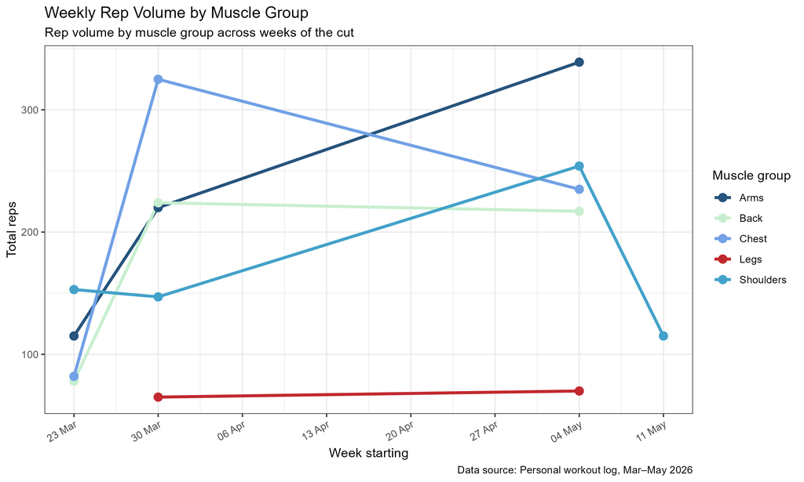

Disregarding the fact that I stopped recording observations after 1/04, we can see that chest dominated my workout plan before 1/04 before declining. Since I’m in a cut, or calorie deficit, I don’t get as much energy to really push for a lot of reps the further into the cut I am. With chest being the most intensive in my program, it makes sense that, the number of reps weekly tend to dip after a period of time. Legs consistently stays at the bottom which makes sense too because I don’t like it.

## Does time of day matter?

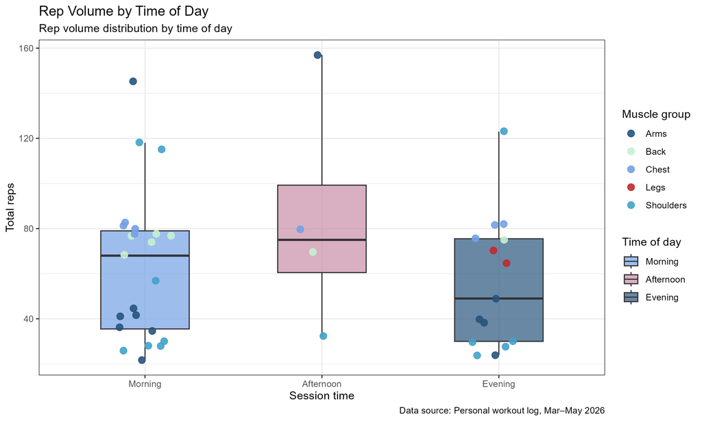

The box plot above highlights the fact that I tend to have a higher rep counts when working out in the afternoon (12pm to 5pm) than any other time as the median sit is the highest during this time. However it’s worth pointing out that Afternoon has the lowest amount of values which means that we have to be careful when making inferences based on this graph. Another thing is, the time of day which I have my workout is completely dependent on my schedule which does not reflect the true effect that time of day might have on my performance for a workout. However, I chose to include this plot because it is interesting in seeing how I allocate my time at the gym in a day.